# Reproducible Research: Peer Assessment 1

## Imputing missing values

```r
num.NA <- sum(is.na(mydata$steps)) # 2304
```

The total number of missing values in the dataset is: 2304

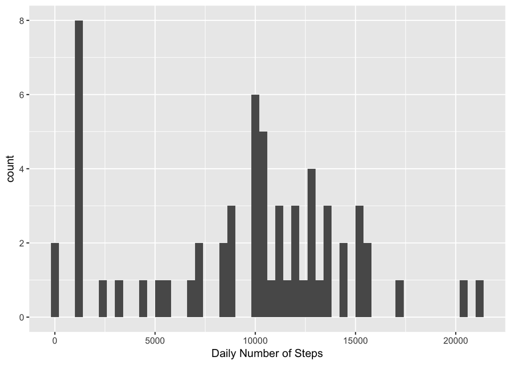

```r
# Replace NAs by the median of the period
step <- data.frame(date = mydata$date[is.na(mydata$steps)],
                    interval = mydata$interval[is.na(mydata$steps)],
                    steps = step.act[match(step.act$interval, mydata$interval[is.na(mydata$steps)]), 3])
mydata2 <- subset(mydata, !is.na(steps))
mydata2 <- rbind(mydata2, step)

step.day2 <- aggregate(mydata2$steps, by = list(mydata2$date), sum, na.rm=TRUE)
names(step.day2) <- c("Date", "steps")

qplot(steps, data = step.day2, geom="histogram", xlab = "Daily Number of Steps", binwidth = 400)
```

```r
step2.mean <- mean(step.day2$steps) # 9503.869
step2.median <- median(step.day2$steps) # 10395
```

## Are there differences in activity patterns between weekdays and weekends?

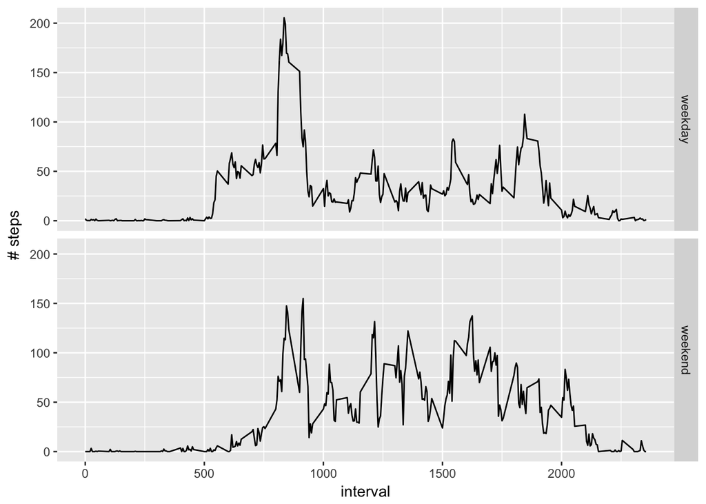

```r
# Create the Weekday/Weekend in new column
mydata2$week <- ifelse(weekdays(mydata2$date) == "Saturday" | weekdays(mydata2$date) == "Sunday" ,"weekend","weekday")

# Recalculate the mean and median for the new colum in step3
step3.mean <- aggregate(mydata2$steps, by = list(mydata2$week, mydata2$interval), mean, na.rm=TRUE)
step3.median <- aggregate(mydata2$steps, by = list(mydata2$week, mydata2$interval), median, na.rm=TRUE)
step3 <- cbind(step3.mean[], step3.median$x)
names(step3) = c("weekday", "interval","step.mean", "step.median")

# Create the graph
ggplot(step3, aes(x = interval, y = step.mean)) + ylab("# steps") + geom_line() + facet_grid(weekday~.)
```

The difference is noticable:

- The weekend, the values are much higher => more walking during the weekend.
- The weekday, we can see that there are also more activity earlier in the morning. And a higher peak in teh morning than in the weekday (probaly when the guy go to work where the distance is higher than what he s doing during the weekend). Then the walking is pretty low which could means that the guy have a job where he is sitting most of the time.